# Rapport IF36

Ahamad MOHAMMAD, Minko Bikono NEIL-JOVY, Simon GELBART, Willen AMICHE

2025-06-14

## **Introduction**

L’objectif de ce projet est d’explorer l’impact des stratégies de recrutement sur les performances sportives des clubs de football et de leurs joueurs. En croisant des statistiques individuelles (performances des joueurs), des données collectives (résultats d’équipes) et les transferts réalisés lors du mercato estival 2022, nous cherchons à identifier les leviers de performance et à mieux comprendre les choix stratégiques opérés par les clubs. Notre analyse se base sur deux saisons complètes (2021-2022 et 2022-2023), afin de mesurer l’évolution des résultats d’une année sur l’autre et de relier cette évolution aux dynamiques de recrutement. À travers plusieurs angles d’analyse (volume de transferts, postes ciblés, valeur marchande, origine des joueurs, rendement, etc.), nous chercherons à répondre à une série de questions permettant de quantifier et qualifier l’effet des recrutements sur la réussite des équipes.

### **📊 Description des variables**

#### - 🧍‍♂️ Player Stats 2021-2022 (`2021-2022 Football Player Stats.csv`)

143 variables – chaque ligne correspond à un joueur pour la saison 2021-2022.

| Variable | Type | Description approximative |
| --- | --- | --- |
| `Rk` | int64 | Rang ou ID du joueur |
| `Player` | object | Nom du joueur |
| `Nation` | object | Nationalité |
| `Pos` | object | Poste |
| `Squad` | object | Club |
| `Comp` | object | Compétition principale |
| `Age` | object | Âge |
| `Born` | object | Année de naissance |
| … | … | …et plus de 130 autres statistiques de jeu : buts, passes, tirs, dribbles, fautes, tacles, interceptions, passes progressives, etc. |
| `AerWon` | float64 | Duels aériens gagnés |
| `AerLost` | float64 | Duels aériens perdus |
| `AerWon%` | float64 | Pourcentage de duels aériens gagnés |

#### - 🏟️ Team Stats 2021-2022 (`2021-2022 Football Team Stats.csv`)

20 variables – chaque ligne correspond à une équipe.

| Variable | Type | Description |
| --- | --- | --- |
| `Rk` | int64 | Rang |
| `Squad` | object | Nom du club |
| `Country` | object | Pays |
| `LgRk` | int64 | Classement dans la ligue |
| `MP`, `W`, `D`, `L` | int64 | Matchs joués, Victoires, Nuls, Défaites |
| `GF`, `GA`, `GD` | int64 | Buts pour, contre, différence |
| `Pts`, `Pts/G` | int64 / float64 | Points et moyenne par match |
| `xG`, `xGA`, `xGD`, `xGD/90` | float64 | Données d’expected goals |
| `Attendance` | int64 | Affluence moyenne |
| `Top Team Scorer` | object | Meilleur buteur |
| `Goalkeeper` | object | Gardien principal |

#### - 🏟️ Team Stats 2022-2023 (`2022-2023 Football Team Stats.csv`)

Même structure et signification que pour 2021-2022, mais avec la saison suivante.

#### - 🔄 Transfers Été 2022 (`2022_2023_football_summer_transfers.csv`)

11 variables – chaque ligne correspond à un transfert.

| Variable | Type | Description |
| --- | --- | --- |
| `name` | object | Nom du joueur transféré |
| `position` | object | Poste |
| `age` | object | Âge |
| `market_value` | object | Valeur estimée |
| `country_from` | object | Pays de départ |
| `league_from` | object | Ligue de départ |
| `club_from` | object | Club de départ |
| `country_to` | object | Pays d’arrivée |
| `league_to` | object | Ligue d’arrivée |
| `club_to` | object | Club d’arrivée |
| `fee` | object | Montant du transfert (peut contenir “Free”, “Loan”, etc.) |

## **Analyse et réponses aux questions**

### **Question 1 : Quels clubs ont le plus recruté par poste (top 20) ?**

#### 🎯 Objectif:

Identifier les **20 clubs les plus actifs** lors du mercato d’été 2022 en termes de nombre de recrues, puis visualiser quels postes ont été ciblés en priorité par ces clubs. Cela permet de mieux comprendre les **stratégies de renforcement** des effectifs selon les lignes de jeu (défense, milieu, attaque).

#### 🧪 Hypothèse :

Nous supposons que les clubs ayant terminé en bas de classement ou nouvellement promus ont davantage recruté, notamment en défense et au milieu, dans une logique de **renforcement pour assurer le maintien**. À l’inverse, les clubs plus stables ou ambitieux auraient fait un recrutement plus ciblé et réparti entre les lignes.

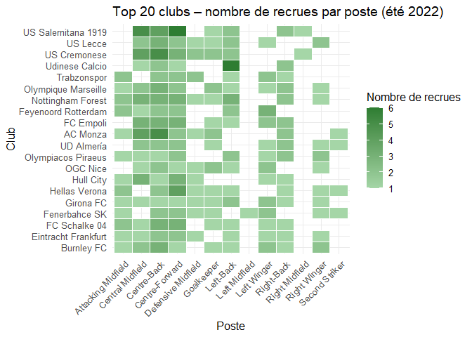

#### 🧠 Interprétation du graphique:

✅ **Conclusion** : l’hypothèse est **globalement confirmée** – les clubs les moins bien classés ont recruté plus, notamment en défense. Toutefois, des exceptions existent, liées à des objectifs plus stratégiques ou spécifiques (comme l’Europe ou le changement d’entraîneur).

### **Question 2: Quels postes sont les plus valorisés sur le marché ?**

#### 🎯 Objectif:

Visualiser la valeur marchande des joueurs par poste pour comprendre quels types de profils sont les plus prisés financièrement sur le marché. Cela permet de hiérarchiser les postes selon leur importance économique dans le football professionnel, sur la base du mercato d’été 2022.

#### 🧪 Hypothèse :

Nous pensons que les **attaquants** seront les plus valorisés sur le marché, en raison de leur impact direct sur les résultats et leur potentiel marketing. Les **défenseurs centraux** et **milieux offensifs** devraient aussi avoir une valeur élevée. À l’inverse, les **gardiens** devraient être en bas de l’échelle.

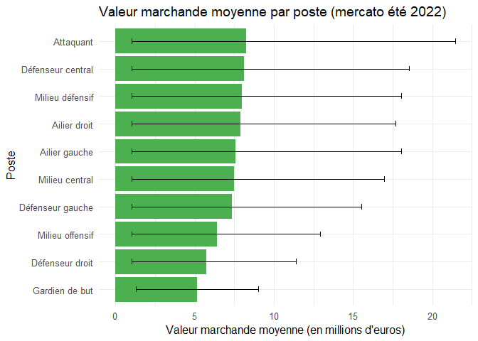

#### 🧠 Interprétation du graphique :

✅ Conclusion : L’hypothèse est largement confirmée. Les attaquants et défenseurs centraux dominent en valeur. L’ajout des barres d’erreur révèle aussi des disparités fortes sur certains postes, notamment offensifs, ce qui enrichit l’analyse au-delà des moyennes seules.

### **Question 3 : Corrélation entre xG (expected goals) et points ?**

#### 🎯 Objectif:

Analyser si le nombre d’expected goals (xG) réalisés par une équipe est corrélé avec son total de points en championnat. Cela permet de vérifier si produire beaucoup d’occasions de qualité est un bon indicateur de performance globale. Les expected goals (xG) mesurent la probabilité qu’un tir se transforme en but, en fonction de facteurs comme la position du tir, le type d’action, l’angle de tir ou la pression défensive. En somme, plus une équipe cumule d’xG, plus elle est censée marquer. Données utilisées : saison 2022-2023.

#### 🧪 Hypothèse :

Nous pensons qu’il existe une **corrélation positive significative** entre les xG et le total de points. Une équipe qui se crée beaucoup d’occasions de qualité a plus de chances de gagner des matchs, même si la finition varie.

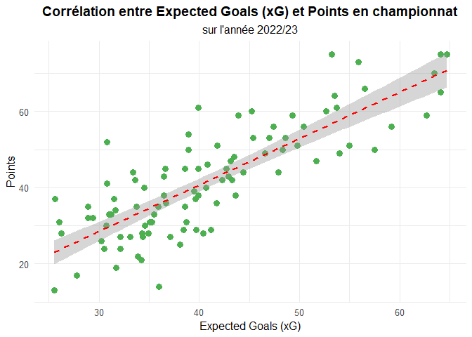

#### 🧠 Interprétation du graphique:

- 🔵 Le nuage de points présente une **tendance linéaire positive** entre les xG et les points, confirmée par la droite de régression.
- 🔵 Cela suggère que les équipes qui se créent beaucoup d’occasions obtiennent en général plus de points, ce qui **valide notre hypothèse**.
- 🔵 Certaines équipes dévient de la tendance (sous-performance ou efficacité maximale), ce qui montre que les xG ne suffisent pas à eux seuls à expliquer les résultats.

✅ **Conclusion** : L’hypothèse est **confirmée**. Il existe une forte corrélation entre production offensive (xG) et performance en championnat.

### **Question 4 : Quel est l’impact des transferts sur la performance des clubs entre 2021-2022 et 2022-2023 ?**

#### 🎯 Objectif:

Analyser l’évolution de la performance des clubs entre deux saisons (2021-2022 ➔ 2022-2023) en fonction de leur nombre de recrues durant l’été 2022. L’objectif est de voir s’il existe une corrélation entre le volume de recrutement et l’évolution du classement.

#### 🧪 Hypothèse :

Nous pensons que les clubs ayant recruté **modérément (4 à 6 joueurs)** progresseront davantage, car ils auront ciblé leurs besoins. Ceux qui ont **recruté massivement** risquent d’avoir des résultats plus hétérogènes à cause du manque de cohésion. Les clubs **n’ayant pas recruté** pourraient stagner ou régresser.

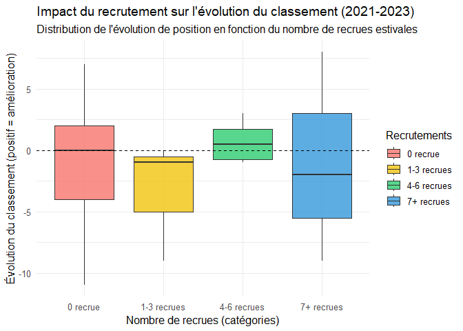

#### 🧠 Interprétation du graphique:

- 🔵 Les clubs n’ayant recruté aucun joueur présentent des résultats très variables, avec une médiane proche de zéro. Cela suggère qu’en l’absence de renfort, il est difficile de progresser de manière structurée, et que la stabilité seule ne suffit pas toujours.
- 🔵 Les clubs ayant recruté entre 1 et 3 joueurs semblent en légère régression. Ce type de recrutement limité peut refléter un ajustement insuffisant face aux besoins de l’effectif.
- 🔵 En revanche, les clubs ayant recruté entre 4 et 6 joueurs enregistrent en moyenne une amélioration de leur classement. Cela semble indiquer qu’un renforcement ciblé, sans bouleverser l’équilibre collectif, est plus efficace.
- 🔵 À l’opposé, les clubs ayant recruté 7 joueurs ou plus affichent une médiane négative et une forte dispersion des résultats. Cela peut s’expliquer par une perte de repères au sein du groupe : remplacer trop de joueurs à la fois nuit à la cohésion et impose de reconstruire l’esprit d’équipe, ce qui peut ralentir les performances sportives.

✅ **Conclusion** : L’hypothèse est **largement confirmée** : un recrutement ciblé et mesuré semble plus bénéfique qu’un mercato massif ou une inaction.

### **Question 5 : Quels sont les transferts les plus coûteux de l’été 2022 ?**

#### 🎯 Objectif:

Identifier les joueurs ayant fait l’objet des transferts les plus onéreux durant le mercato estival 2022, afin de mieux comprendre où se concentrent les plus gros investissements du marché.

#### 🧪 Hypothèse :

Les attaquants et les jeunes espoirs prometteurs devraient constituer la majorité des transferts les plus chers, notamment en direction des grands clubs européens.

[figure not shown]

#### 🎯 Objectif:

Mesurer la contribution directe des joueurs recrutés à l’été 2022 dans le total des buts marqués par leur club en 2022-2023.

#### 🧪 Hypothèse :

Les recrues, devraient représenter une part importante des buts dans les clubs ayant beaucoup investi.

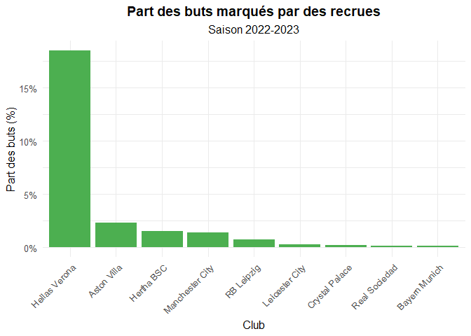

#### 🧠 Interprétation du graphique:

✅ **Conclusion** : L’hypothèse est partiellement confirmée. Dans certains clubs, les recrues ont été déterminantes offensivement. Dans d’autres, leur impact a été plus indirect. La contribution dépend donc fortement du profil des joueurs recrutés et du besoin tactique identifié.

### **Question 7 : Quel est le rendement des recrues vs anciens**

#### 🎯 Objectif:

Comparer l’efficacité offensive des recrues vs les joueurs déjà présents.

#### 🧪 Hypothèse :

Les joueurs déjà intégrés au collectif devraient avoir un meilleur rendement offensif, car les recrues ont souvent besoin de temps pour s’adapter.

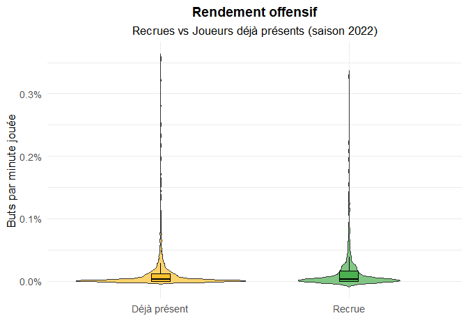

### **Question 8 : Recrutement local vs international? (top 15)**

#### 🎯 Objectif:

Visualiser la répartition géographique du top 15 des recrutements pour évaluer dans quelle mesure les clubs recrutent localement ou à l’international.

#### 🧪 Hypothèse :

Les grands clubs européens recrutent principalement à l’international, tandis que les clubs de second rang privilégient les transferts nationaux pour des raisons de coût et de logistique.

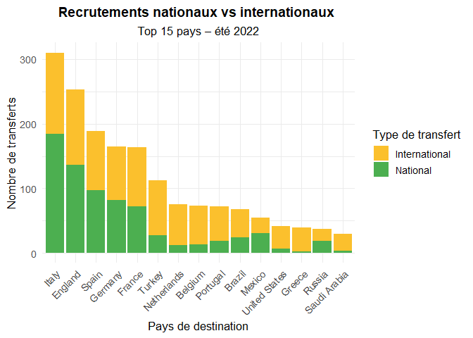

### **Question 9 : Quels clubs misent sur des jeunes joueurs ?**

#### 🎯 Objectif:

Identifier les clubs qui intègrent le plus de jeunes joueurs dans leur effectif et leur donnent du temps de jeu.

#### 🧪 Hypothèse :

Certains clubs, notamment ceux ayant une stratégie axée sur la formation ou la revente de joueurs (comme RB Salzburg, l’Ajax ou Barcelone), misent davantage sur les jeunes talents, tant en nombre qu’en minutes jouées. On peut également s’attendre à observer une forte présence de jeunes joueurs dans les clubs des championnats français et espagnol, ces pays disposant de viviers de talents particulièrement importants et n’hésite pas à former de jeunes joueurs. Par ailleurs, les clubs disposant de moyens financiers plus limités ont souvent tendance à faire davantage confiance aux jeunes joueurs, qui représentent une alternative plus économique

[figure not shown]

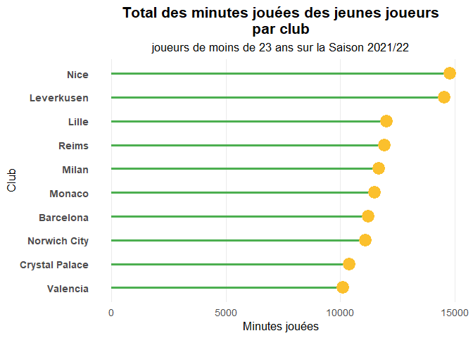

#### 🧠 Interprétation des graphiques:

✅ **Conclusion** :L’hypothèse est donc globalement confirmée : les clubs avec une stratégie de formation claire jouent davantage leurs jeunes talents, comme en témoignent les chiffres en nombre de joueurs et en minutes jouées. Cependant, la diversité des situations montre que ce n’est pas uniquement une question de moyens financiers, mais surtout d’efficacité des centres de formation et de la politique sportive adoptée. Cette analyse souligne donc l’importance de la formation comme facteur clé de succès pour les clubs souhaitant valoriser leurs jeunes joueurs sur le long terme

### **Question 10 : Quelles équipes sont les plus “chanceuses” ou “malchanceuses” ?**

#### 🎯 Objectif:

Identifier les équipes dont le nombre de buts marqués est significativement supérieur ou inférieur à leur expected goals (xG) sur la saison 2021/2022. Cela permet de mettre en évidence celles qui dépassent les attentes en convertissant efficacement leurs occasions (équipes « chanceuses »), et celles qui, malgré beaucoup d’occasions créées (xG élevé), peinent à concrétiser (équipes « malchanceuses »). On ne se basera que sur les grands championnats pour essayer d’établir une corrélation avec la place dans le classement cette année la.

#### 🧪 Hypothèse :

Il paraît plausible que les équipes les mieux classées dans leur championnat ont tendance à être « chanceuses », c’est-à-dire qu’elles marquent plus de buts que ce que leur expected goals (xG) prédit, grâce à une meilleure finition et une efficacité offensive supérieure. En revanche, les équipes moins bien classées que ce qu’elle devrait, malgré un xG parfois élevé, peinent à convertir leurs occasions, ce qui les rend « malchanceuses » et reflète un manque de réalisme devant le but ou une qualité individuelle moindre.

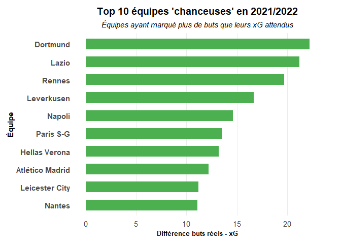

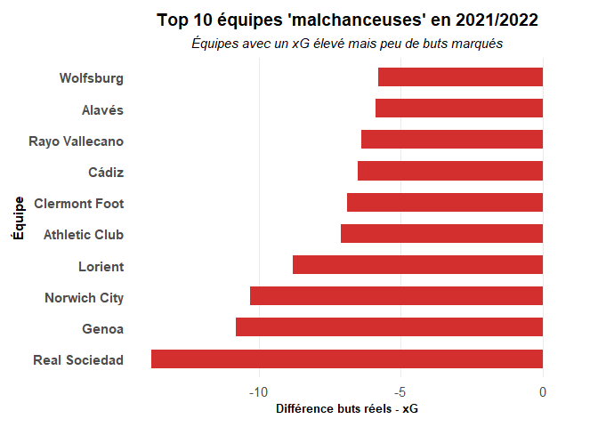

#### 🧠 Interprétation du graphique:

- 🔵 Une corrélation apparaît entre les équipes “chanceuses” (ayant marqué plus de buts que leurs xG) et leur performance en championnat.
- 🔵 Parmi ces équipes : **Dortmund (2ᵉ Bundesliga)**, **Lazio (5ᵉ Serie A)**, **Rennes (4ᵉ Ligue 1)**, **Leverkusen (3ᵉ Bundesliga)**, **Naples (3ᵉ Serie A)** et **PSG (champion de Ligue 1)**. Hormis les très grands clubs comme le PSG, ces équipes ont souvent réalisé l’une de leurs meilleures saisons.
- 🔵 Des clubs comme **Hellas Vérone (9ᵉ en Serie A cette saison-là, 17ᵉ la suivante)** ou **Nantes (9ᵉ en Ligue 1, contre 18ᵉ puis 17ᵉ les saisons encadrantes)** témoignent également de performances supérieures à leur niveau habituel, suggérant une **saison de surperformance**.
- 🔵 À l’inverse, les équipes “malchanceuses” (xG élevés mais peu de buts marqués) sont souvent bien classées : **Real Sociedad (6ᵉ)**, **Genoa (11ᵉ)**, **Lorient (10ᵉ)**, **Athletic Club (8ᵉ)**, **Clermont (8ᵉ)**, **Rayo Vallecano (12ᵉ)**, **Wolfsburg (12ᵉ)**. Leur bon classement s’explique par une capacité à se créer de nombreuses occasions, sans les concrétiser pleinement.
- 🔵 Enfin, des équipes comme **Norwich** ou **Alavés**, derniers de leurs championnats, montrent que la “malchance” ne suffit pas toujours à expliquer les résultats : certaines saisons sont simplement ratées dans leur ensemble.

✅ **Conclusion** :

Les équipes “chanceuses”, qui marquent plus que leurs expected goals (xG), sont souvent bien classées et en surperformance. À l’inverse, certaines équipes “malchanceuses” restent compétitives malgré un manque d’efficacité offensive. L’écart entre buts et xG influence le classement, mais ne l’explique pas entièrement.

#### 🧪 Hypothèse :

Nous formulons l’hypothèse que chaque défenseur excelle dans un type d’intervention défensive qui correspond à :son style de jeu personnel,les besoins spécifiques de son équipe, ou encore aux caractéristiques du championnat dans lequel il évolue. Par exemple, un joueur comme Virgil van Dijk pourrait exceller dans les duels aériens en raison du rythme physique de la Premier League, tandis que David Alaba aurait un profil plus polyvalent ou technique adapté au style de jeu du Real Madrid en Liga.

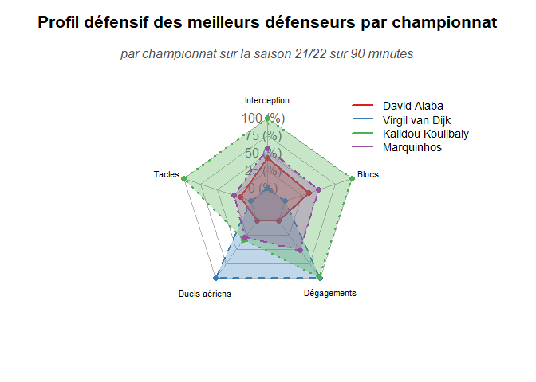

#### 🧠 Interprétation du graphique:

- 🔵 Le radar chart permet de comparer les performances de Virgil van Dijk (Premier League), Marquinhos (Ligue 1), Kalidou Koulibaly (Serie A) et David Alaba (La Liga), chacun représenté par une couleur distincte.
- 🔵 Van Dijk domine nettement les duels aériens, ce qui confirme son rôle de tour de contrôle défensive au sein de Liverpool et son importance dans le jeu aérien.
- 🔵 Marquinhos présente un profil très équilibré, avec des performances solides sur l’ensemble des dimensions défensives, reflétant sa régularité et sa polyvalence au PSG.
- 🔵 Koulibaly se distingue particulièrement par son volume de dégagements et de blocs, traduisant une approche défensive réactive, physique et axée sur l’interruption du jeu adverse.
- 🔵 Alaba, en revanche, affiche un profil moins basé sur l’impact physique ; ses statistiques reflètent davantage son rôle hybride entre défenseur et milieu dans un système de possession comme celui du Real Madrid.

✅ **Conclusion** :

Cette visualisation met en lumière la diversité des profils défensifs au plus haut niveau européen. Chaque joueur excelle dans des dimensions différentes, illustrant que la performance défensive ne se limite pas à une seule statistique, mais dépend de l’environnement tactique, du style d’équipe et du championnat. Le radar chart est ici un outil efficace pour identifier les points forts et les spécialisations de chacun, tout en offrant une représentation synthétique d’indicateurs hétérogènes mais complémentaires.

### **Question 12 : Quels clubs sont les plus dépendants de leur meilleur buteur ?**

#### 🎯 Objectif:

Évaluer dans quelle mesure chaque club dépend de son meilleur buteur pour marquer des buts lors de la saison 2021-2022.

#### 🧪 Hypothèse :

Certains clubs dépendent fortement d’un seul joueur pour marquer des buts. Cette dépendance peut poser un risque stratégique (blessure, transfert, méforme).

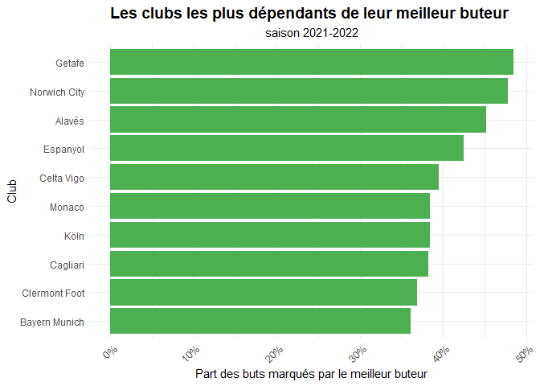

#### 🧠 Interprétation du graphique:

- 🔵 Le graphique illustre la part des buts marqués par le meilleur buteur de chaque club, mettant en évidence leur dépendance offensive à un seul joueur.
- 🔵 Getafe est l’équipe la plus dépendante, avec près de 48 % de ses buts inscrits par Enes Ünal, suivi de Norwich City, dont Teemu Pukki a marqué également 48 % des buts du club.
- 🔵 Des clubs comme Alavés ou Espanyol affichent eux aussi une forte dépendance offensive, dépassant le seuil de 40 % de buts venant d’un seul joueur.
- 🔵 Ce niveau de concentration du scoring rend ces équipes vulnérables : l’absence ou la méforme de leur buteur principal peut fortement pénaliser leur efficacité offensive globale.

✅ **Conclusion** :  
Ce graphique met en évidence que certains clubs reposent quasiment à moitié sur un seul joueur pour marquer. Cela suggère une dépendance tactique risquée, qui devrait être prise en compte dans la stratégie sportive (recrutement, distribution du jeu, etc.). À l’inverse, les clubs avec une dépendance plus faible bénéficient d’un jeu offensif plus collectif, souvent plus résilient à l’échelle d’une saison.

### **Question 13 : Quels sont les meilleurs milieux de terrain en termes de création ?**

#### 🎯 Objectif:

Identifier les milieux de terrain les plus créatifs lors de la saison 2021-2022 en combinant plusieurs indicateurs : passes clés, passes décisives, passes dans la surface, et passes menant à des tirs.

#### 🧪 Hypothèse :

Un milieu créatif ne se limite pas aux passes décisives. Les meilleurs créateurs sont ceux qui préparent les occasions, pénètrent dans les zones dangereuses et participent activement à la construction offensive.

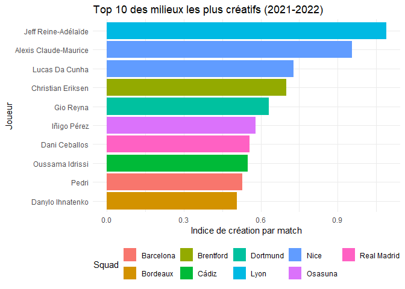

#### 🧠 Interprétation du graphique:

- 🔵 L’indice présenté combine quatre dimensions clés de la création offensive : Assists (passes décisives), PasAss (passes clés), PPA (passes vers la surface), et ScaPassLive (passes en jeu menant à un tir).
- 🔵 En rapportant ces données au nombre de matchs joués, on obtient un indice normalisé, ce qui permet une comparaison équitable entre joueurs, quelle que soit leur durée de jeu.
- 🔵 Cet indice offre une vision globale de la contribution offensive par la passe, en allant au-delà des seules passes décisives pour inclure la préparation des actions dangereuses.

✅ **Conclusion** :

Cette approche met en lumière les milieux les plus impliqués dans la création offensive, qu’ils soient passeurs décisifs, régulateurs du jeu ou moteurs de la progression du ballon. Elle montre que la créativité ne se limite pas aux passes décisives visibles, mais aussi à la construction d’occasions, essentielle au jeu moderne.

### **Question 14 : Volume des transferts par ligue de départ**

#### 🎯 Objectif:

Analyser quel championnat (ligue) est à l’origine du plus grand nombre de transferts durant l’été 2022. Cela aide à repérer les championnats qui forment beaucoup de joueurs ou qui ont une stratégie de vente active.

#### 🧪 Hypothèse :

Les ligues les plus réputées financièrement (ex : Premier League, Liga, Bundesliga) exportent plus de joueurs, mais certains championnats moins connus (Amérique du Sud) peuvent aussi être des promoteurs importants de jeunes talents.

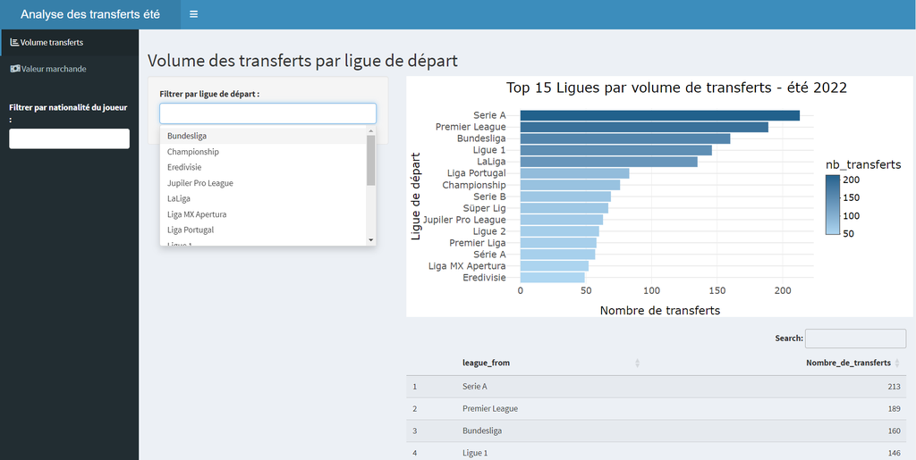

### **Question 15 : Valeur marchande des transferts selon pays et ligue de départ**

#### 🎯 Objectif:

Étudier la répartition de la valeur totale des transferts par pays et ligue d’origine, afin d’identifier où les clubs réalisent les investissements les plus élevés et d’identifier les marchés les plus chers.

#### 🧪 Hypothèse :

Les pays et ligues les plus riches ou les plus attractifs devraient générer des transferts avec des valeurs plus élevées. On s’attend donc à une concentration forte sur quelques ligues majeures (le top 5 ligues européennes).

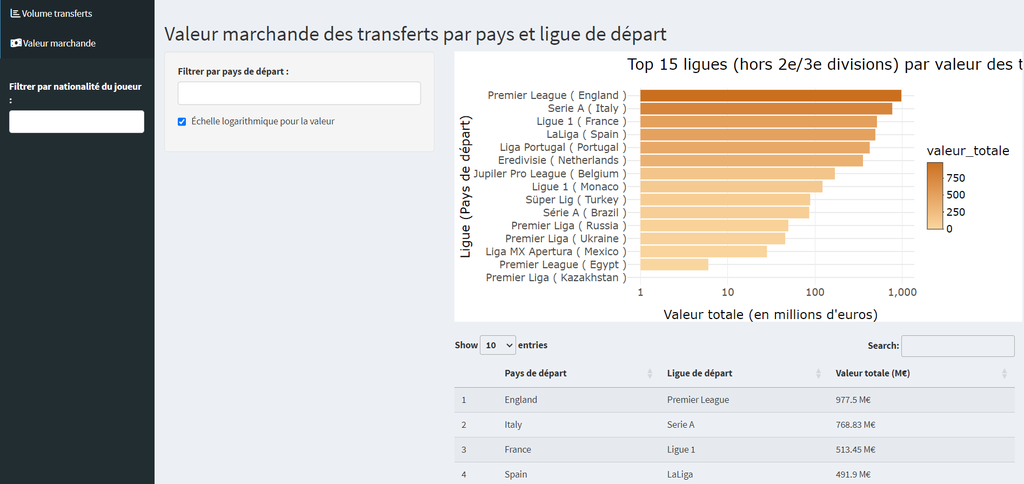

#### 🧠 Interprétation du graphique:

✅ **Conclusion** :  
Les analyses quantitatives (volume de transferts) et financières (valeur des transferts) se complètent pour montrer que les grands championnats européens dominent largement le marché des transferts estivaux. Ces ligues ont non seulement le plus grand nombre de joueurs transférés, mais aussi les montants financiers les plus élevés. Cela reflète leur capacité à attirer, former et valoriser les talents, ainsi que leur poids économique et médiatique. Par ailleurs, la valeur marchande d’un joueur dépend non seulement de son talent individuel, mais aussi de son championnat d’origine, sa visibilité et la dynamique du marché.

### **Question 16 : Quel pays a accueilli le plus de joueurs coûteux durant le mercato d’été 2022 ?**

#### 🎯 Objectif:

Identifier les pays qui attirent le plus de joueurs en termes de volume financier

#### 🧪 Hypothèse :

Les clubs Europeens attirent plus de joueurs que ceux d’autres pays grâce à leur pouvoir d’achat élevé

[figure not shown]

#### 🧠 Interprétation du graphique:

✅ **Conclusion** :  
Les dépenses de transferts en 2022 confirment la domination des grandes puissances européennes du football, avec une concentration marquée en Europe de l’Ouest. Cela reflète non seulement les moyens financiers de ces pays, mais aussi leur attractivité dans le marché mondial des joueurs.

### **Question 17 : Quels clubs ont le plus contribué à la performance offensive de leur pays ?**

#### 🎯 Objectif:

Analyser comment les clubs participent au total de **buts marqués** dans chaque pays

#### 🧪 Hypothèse :

Les gros clubs (comme Manchester City ou PSG) représentent une part importante des buts de leur pays

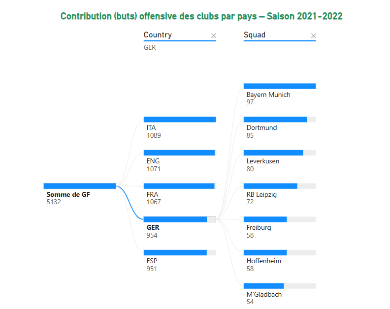

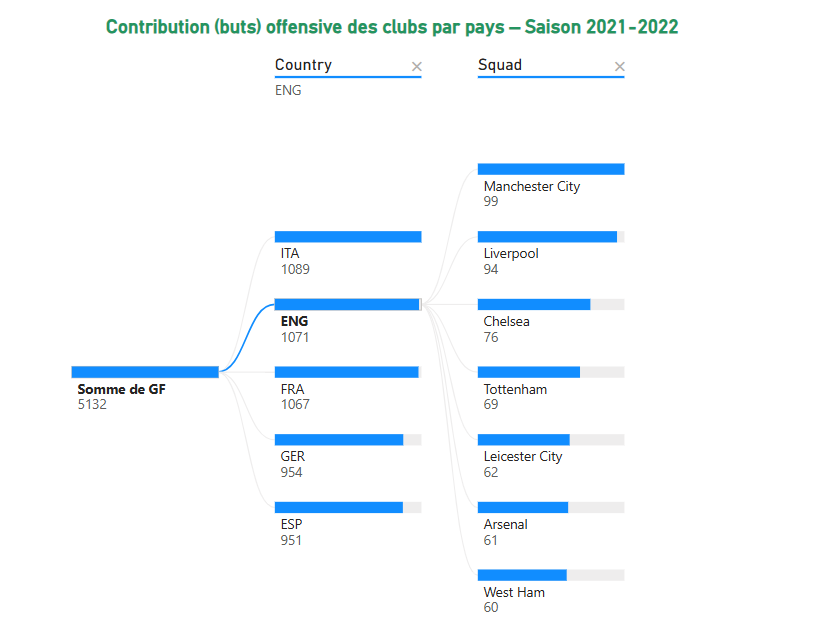

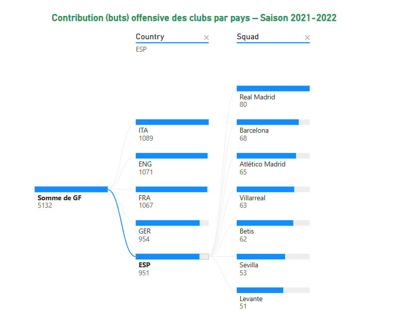

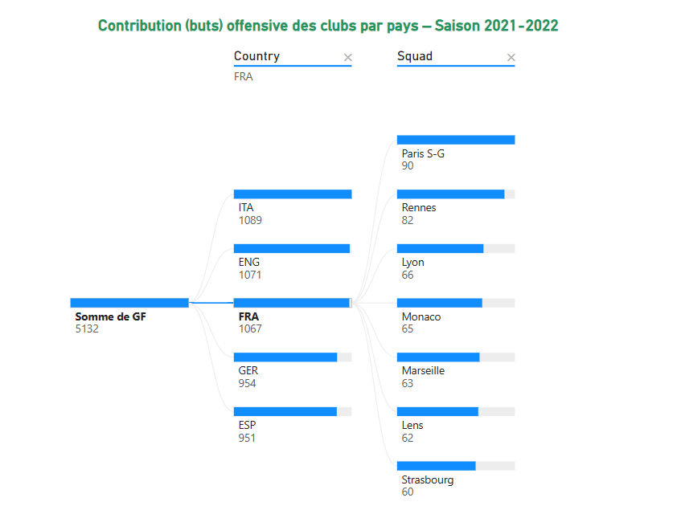

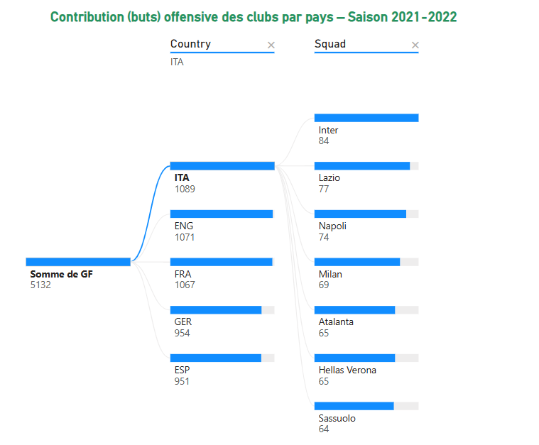

#### 🧠 Interprétation du graphique:

✅ **Conclusion** :  
La performance offensive des pays repose largement sur quelques clubs dominants, ce qui renforce leur rôle central dans leurs championnats respectifs. Cette concentration des buts traduit une inégalité sportive fréquente dans les grandes ligues européennes.

## **Conclusion Générale**

Ce projet nous a permis d’explorer en profondeur les dynamiques du marché des transferts dans le football européen, en croisant des données de performance individuelles, collectives et économiques. Nous avons mis en évidence plusieurs faits marquants : les clubs recrutent différemment selon leur statut (ambitieux vs en lutte pour le maintien), la valeur marchande varie fortement selon le poste, et un recrutement ciblé est généralement plus efficace qu’un mercato massif.

Nos analyses confirment que les investissements ne garantissent pas une amélioration des performances sportives, et qu’un bon recrutement repose autant sur la cohérence tactique que sur les moyens financiers. L’approche multi-angle (corrélations, rendements, contributions offensives, dépendances, etc.) a enrichi notre compréhension du lien entre stratégie de recrutement et performance.

### 🧱 Difficultés rencontrées :

- L’hétérogénéité des formats dans les fichiers de données (problèmes d’encodage,valeurs textuelles à nettoyer) a été un frein important au début.
- Certaines données manquaient de précision ou étaient difficiles à relier directement (par exemple, le lien exact entre certains joueurs transférés et leurs statistiques après transfert).

### 🔍 Pistes d’approfondissement :

- Suivre les **performances des recrues tout au long de la saison** pour distinguer l’impact immédiat vs différé.
- Analyser aussi le **coût par point gagné** ou par but marqué pour chaque club, afin de relier investissement et efficacité.

### 🗣️ Retour individuel :

- **Ahamad MOHAMMAD** : Ce projet m’a permis de mettre en œuvre les concepts d’ergonomie graphique, de narration visuelle et de contraste abordés pendant le cours. J’ai apprécié expérimenter avec `fmsb` et `shiny` pour créer des visualisations interactives, tout en tenant compte de la lisibilité et de l’impact visuel. La comparaison entre R et des outils comme Tableau m’a aidé à mieux comprendre les cas d’usage de chaque outil. Je suis globalement très satisfait de ce cours.
- **Minko Bikono NEIL-JOVY** : J’ai renforcé ma maîtrise de `dplyr` et `tidyverse`, tout en prenant conscience de l’importance de la clarté visuelle dans la restitution des résultats. Les apports du cours sur la psychologie des couleurs et les chart types adaptés m’ont aidé à structurer des visualisations efficaces. Les échanges autour de Power BI ont également enrichi ma culture des outils BI. Ce projet a été formateur, et je repars avec des bases solides en data visualisation.
- **Simon GELBART** : Ce projet m’a vraiment permis de progresser en visualisation de données. J’ai pu maîtriser ggplot2 et mettre en pratique les notions vues en cours, comme le choix cohérent des couleurs ou l’importance d’un bon équilibre visuel. J’ai aussi exploré des packages comme ggimage pour rendre les graphiques plus parlants et accrocheurs. J’ai pris le temps de soigner les titres, les légendes et les axes pour que chaque graphique soit clair et facile à lire. Ce travail m’a fait réaliser à quel point le design graphique joue un rôle essentiel pour bien faire passer un message. J’ai trouvé l’approche du cours à la fois concrète et stimulante, et je repars avec des bases solides pour la suite.
- **Willen AMICHE** : J’ai découvert la force des visualisations narratives dans un projet analytique structuré, en lien direct avec les principes abordés en cours (cohérence visuelle, perception). J’ai pris en compte les conseils sur l’organisation de l’information et les bons usages de la couleur pour renforcer l’impact de mes graphiques. Les travaux sur Power BI m’ont permis de situer R dans un écosystème plus large. Ce projet a solidifié ma compréhension de la data visualisation, et je ressors très satisfait du contenu et de la pédagogie du cours.

## **Annexe – Répartition du travail**

### 🔄 Répartition des analyses :

- **Ahamad MOHAMMAD** : responsable des analyses liées aux expected goals et à la performance offensive. Il a également conçu l’application Shiny, en lien avec les travaux exploratoires sur l’interactivité en data visualisation.
- **Minko Bikono NEIL-JOVY** : chargé des analyses de structure de marché, de profils de recrues et de distribution des postes. Il a structuré l’ensemble du rapport RMarkdown et piloté l’exploration comparative avec Power BI.
- **Simon GELBART** : a réalisé les visualisations sur la dépendance aux buteurs, la formation des jeunes, et les comparaisons inter-ligues. Il a aussi contribué à l’analyse de la cohérence stratégique des recrutements et à corrigé/supervisé certains graphiques notamment dans la mise en page.
- **Willen AMICHE** : a pris en charge les questions sur l’impact du volume de recrutement et la rentabilité sportive, ainsi que la rédaction de plusieurs interprétations graphiques et de la conclusion générale.

### ✍️ Travaux collectifs :

- La définition des hypothèses, la rédaction des interprétations et conclusions, ainsi que la relecture globale ont été menées de manière collaborative.
- Tous les membres ont contribué au dépôt GitHub, au choix des visualisations, à la sélection des indicateurs pertinents et à la validation finale du rendu.

## **Bibliographie**

- **Mr FALIP Joris**. *Cours IF36 – Visualisation de données*. Disponible sur : https://if36.dataframe.fr
- **The Data Viz Catalogue**. *Une bibliothèque des différents types de visualisations de données*. Disponible sur : https://datavizcatalogue.com
- **Udemy**. *Devenir un expert de Power BI – La formation complète*. Disponible sur : https://www.udemy.com/course/devenir-un-expert-de-power-bi-la-formation-complete/
- **OpenAI ChatGPT**. *Assistance à la simplification et à l’optimisation de code R pour des visualisations plus rapides et efficaces*. https://chat.openai.com